# 6. Worksheet: Among Site (Beta) Diversity – Part 1

Student Name; Z620: Quantitative Biodiversity, Indiana University

04 February, 2025

## OVERVIEW

In this worksheet, we move beyond the investigation of within-site $\alpha$-diversity. We will explore $\beta$-diversity, which is defined as the diversity that occurs among sites. This requires that we examine the compositional similarity of assemblages that vary in space or time.

After completing this exercise you will know how to:

1. formally quantify $\beta$-diversity
2. visualize $\beta$-diversity with heatmaps, cluster analysis, and ordination
3. test hypotheses about $\beta$-diversity using multivariate statistics

## Directions:

1. In the Markdown version of this document in your cloned repo, change “Student Name” on line 3 (above) with your name.
2. Complete as much of the worksheet as possible during class.
3. Use the handout as a guide; it contains a more complete description of data sets along with examples of proper scripting needed to carry out the exercises.
4. Answer questions in the worksheet. Space for your answers is provided in this document and is indicated by the “>” character. If you need a second paragraph be sure to start the first line with “>”. You should notice that the answer is highlighted in green by RStudio (color may vary if you changed the editor theme).
5. Before you leave the classroom, **push** this file to your GitHub repo.
6. For the assignment portion of the worksheet, follow the directions at the bottom of this file.
7. When you are done, **Knit** the text and code into a PDF file.
8. After Knitting, submit the completed exercise by creating a **pull request** via GitHub. Your pull request should include this file (**6.BetaDiversity_1_Worksheet.Rmd**) with all code blocks filled out and questions answered) and the PDF output of `Knitr`  
   (**6.BetaDiversity_1_Worksheet.pdf**).

The completed exercise is due on **Wednesday, February 5<sup>th</sup>, 2025 before 12:00 PM (noon)**.

## 1) R SETUP

Typically, the first thing you will do in either an R script or an RMarkdown file is setup your environment. This includes things such as setting the working directory and loading any packages that you will need.

In the R code chunk below, please provide the code to:

1. Clear your R environment,
2. Print your current working directory,
3. Set your working directory to your `Week3-Beta/` folder folder, and
4. Load the `vegan` R package (be sure to install first if you have not already).

```r
rm(list = ls())
getwd()
```

```
## [1] "/cloud/project/QB2025_Guevara/Week3-Beta"
```

````r
setwd("/cloud/project/QB2025_Guevara/Week3-Beta")

#If we do ```{r, include = FALSE}, the whole R chunk will not be printed in the knitted file.
````

## 2) LOADING DATA

### Load dataset

In the R code chunk below, do the following:

1. load the `doubs` dataset from the `ade4` package, and
2. explore the structure of the dataset.

```r
# note, please do not print the dataset when submitting
package.list <- c('vegan', 'ade4', 'viridis', 'gplots', 'BiodiversityR', 'indicspecies')
for (package in package.list){
  if (!require(package, character.only = TRUE, quietly = TRUE)) {
    install.packages(package)
    library(package, character.only = TRUE)
  }
}
```

```
## BiodiversityR 2.17-1.1: Use command BiodiversityRGUI() to launch the Graphical User Interface;
## to see changes use BiodiversityRGUI(changeLog=TRUE, backward.compatibility.messages=TRUE)
```

```r
library(vegan)
data(doubs)
#doubs is our list, fish is our object in this case
doubs$fish
```

|  | Cogo | Satr | Phph | Neba | Thth | Teso | Chna | Chto | Lele | Lece | Baba | Spbi | Gogo | Eslu | Pefl | Rham | Legi | Scer | Cyca | Titi | Abbr | Icme | Acce | Ruru | Blbj | Alal | Anan |
| --- | --- | --- | --- | --- | --- | --- | --- | --- | --- | --- | --- | --- | --- | --- | --- | --- | --- | --- | --- | --- | --- | --- | --- | --- | --- | --- | --- |
| 1 | 0 | 3 | 0 | 0 | 0 | 0 | 0 | 0 | 0 | 0 | 0 | 0 | 0 | 0 | 0 | 0 | 0 | 0 | 0 | 0 | 0 | 0 | 0 | 0 | 0 | 0 | 0 |
| 2 | 0 | 5 | 4 | 3 | 0 | 0 | 0 | 0 | 0 | 0 | 0 | 0 | 0 | 0 | 0 | 0 | 0 | 0 | 0 | 0 | 0 | 0 | 0 | 0 | 0 | 0 | 0 |
| 3 | 0 | 5 | 5 | 5 | 0 | 0 | 0 | 0 | 0 | 0 | 0 | 0 | 0 | 1 | 0 | 0 | 0 | 0 | 0 | 0 | 0 | 0 | 0 | 0 | 0 | 0 | 0 |
| 4 | 0 | 4 | 5 | 5 | 0 | 0 | 0 | 0 | 0 | 1 | 0 | 0 | 1 | 2 | 2 | 0 | 0 | 0 | 0 | 1 | 0 | 0 | 0 | 0 | 0 | 0 | 0 |
| 5 | 0 | 2 | 3 | 2 | 0 | 0 | 0 | 0 | 5 | 2 | 0 | 0 | 2 | 4 | 4 | 0 | 0 | 2 | 0 | 3 | 0 | 0 | 0 | 5 | 0 | 0 | 0 |
| 6 | 0 | 3 | 4 | 5 | 0 | 0 | 0 | 0 | 1 | 2 | 0 | 0 | 1 | 1 | 1 | 0 | 0 | 0 | 0 | 2 | 0 | 0 | 0 | 1 | 0 | 0 | 0 |
| 7 | 0 | 5 | 4 | 5 | 0 | 0 | 0 | 0 | 1 | 1 | 0 | 0 | 0 | 0 | 0 | 0 | 0 | 0 | 0 | 0 | 0 | 0 | 0 | 0 | 0 | 0 | 0 |
| 8 | 0 | 0 | 0 | 0 | 0 | 0 | 0 | 0 | 0 | 0 | 0 | 0 | 0 | 0 | 0 | 0 | 0 | 0 | 0 | 0 | 0 | 0 | 0 | 0 | 0 | 0 | 0 |
| 9 | 0 | 0 | 1 | 3 | 0 | 0 | 0 | 0 | 0 | 5 | 0 | 0 | 0 | 0 | 0 | 0 | 0 | 0 | 0 | 1 | 0 | 0 | 0 | 4 | 0 | 0 | 0 |
| 10 | 0 | 1 | 4 | 4 | 0 | 0 | 0 | 0 | 2 | 2 | 0 | 0 | 1 | 0 | 0 | 0 | 0 | 0 | 0 | 0 | 0 | 0 | 0 | 0 | 0 | 0 | 0 |

[output cut: 20 more lines]

```r
str(doubs, max.level = 1)
```

```
## List of 4
##  $ env    :'data.frame': 30 obs. of  11 variables:
##  $ fish   :'data.frame': 30 obs. of  27 variables:
##  $ xy     :'data.frame': 30 obs. of  2 variables:
##  $ species:'data.frame': 27 obs. of  4 variables:
```

```r
head(doubs$env)
```

|  | dfs | alt | slo | flo | pH | har | pho | nit | amm | oxy | bdo |
| --- | --- | --- | --- | --- | --- | --- | --- | --- | --- | --- | --- |
| 1 | 3 | 934 | 6.176 | 84 | 79 | 45 | 1 | 20 | 0 | 122 | 27 |
| 2 | 22 | 932 | 3.434 | 100 | 80 | 40 | 2 | 20 | 10 | 103 | 19 |
| 3 | 102 | 914 | 3.638 | 180 | 83 | 52 | 5 | 22 | 5 | 105 | 35 |
| 4 | 185 | 854 | 3.497 | 253 | 80 | 72 | 10 | 21 | 0 | 110 | 13 |
| 5 | 215 | 849 | 3.178 | 264 | 81 | 84 | 38 | 52 | 20 | 80 | 62 |
| 6 | 324 | 846 | 3.497 | 286 | 79 | 60 | 20 | 15 | 0 | 102 | 53 |

```r
head(doubs$fish)
```

|  | Cogo | Satr | Phph | Neba | Thth | Teso | Chna | Chto | Lele | Lece | Baba | Spbi | Gogo | Eslu | Pefl | Rham | Legi | Scer | Cyca | Titi | Abbr | Icme | Acce | Ruru | Blbj | Alal | Anan |
| --- | --- | --- | --- | --- | --- | --- | --- | --- | --- | --- | --- | --- | --- | --- | --- | --- | --- | --- | --- | --- | --- | --- | --- | --- | --- | --- | --- |
| 1 | 0 | 3 | 0 | 0 | 0 | 0 | 0 | 0 | 0 | 0 | 0 | 0 | 0 | 0 | 0 | 0 | 0 | 0 | 0 | 0 | 0 | 0 | 0 | 0 | 0 | 0 | 0 |
| 2 | 0 | 5 | 4 | 3 | 0 | 0 | 0 | 0 | 0 | 0 | 0 | 0 | 0 | 0 | 0 | 0 | 0 | 0 | 0 | 0 | 0 | 0 | 0 | 0 | 0 | 0 | 0 |
| 3 | 0 | 5 | 5 | 5 | 0 | 0 | 0 | 0 | 0 | 0 | 0 | 0 | 0 | 1 | 0 | 0 | 0 | 0 | 0 | 0 | 0 | 0 | 0 | 0 | 0 | 0 | 0 |
| 4 | 0 | 4 | 5 | 5 | 0 | 0 | 0 | 0 | 0 | 1 | 0 | 0 | 1 | 2 | 2 | 0 | 0 | 0 | 0 | 1 | 0 | 0 | 0 | 0 | 0 | 0 | 0 |
| 5 | 0 | 2 | 3 | 2 | 0 | 0 | 0 | 0 | 5 | 2 | 0 | 0 | 2 | 4 | 4 | 0 | 0 | 2 | 0 | 3 | 0 | 0 | 0 | 5 | 0 | 0 | 0 |
| 6 | 0 | 3 | 4 | 5 | 0 | 0 | 0 | 0 | 1 | 2 | 0 | 0 | 1 | 1 | 1 | 0 | 0 | 0 | 0 | 2 | 0 | 0 | 0 | 1 | 0 | 0 | 0 |

```r
? head
```

*Question 1*: Describe some of the attributes of the `doubs` dataset.

1. How many objects are in `doubs`?
2. How many fish species are there in the `doubs` dataset?
3. How many sites are in the `doubs` dataset?

> *Answer 1a*: There are 4 objects in ‘doubs’, where each object is its own data.frame (fish, env, xy, and species). *Answer 1b*: There are 27 species of fish in the doubs dataset *Answer 1c*: There are 30 sites in the doubs dataset

### Visualizing the Doubs River Dataset

*Question 2*: Answer the following questions based on the spatial patterns of richness (i.e., $\alpha$-diversity) and Brown Trout (*Salmo trutta*) abundance in the Doubs River.

1. How does fish richness vary along the sampled reach of the Doubs River?
2. How does Brown Trout (*Salmo trutta*) abundance vary along the sampled reach of the Doubs River?
3. What do these patterns say about the limitations of using richness when examining patterns of biodiversity?

## 3) QUANTIFYING BETA-DIVERSITY

In the R code chunk below, do the following:

1. write a function (`beta.w()`) to calculate Whittaker’s $\beta$-diversity (i.e., $\beta_{w}$) that accepts a site-by-species matrix with optional arguments to specify pairwise turnover between two sites, and
2. use this function to analyze various aspects of $\beta$-diversity in the Doubs River.

```r
beta.w <- function(site.by.species = ""){
  SbyS.pa <- decostand(site.byspecies, method = "pa")
  #convert to presence-absence
  S <- ncol(SbyS.pa[,which(colSums(SbyS.pa) > 0 )])
  # number of species in the region
  a.bar <- mean(specnumber(SbyS.pa))
  #average richness at each site
  b.w <- round(S/a.bar, 3)
  #round to 3 decimal places
  return(b.w)
}

#Turnover between two sites
beta.w <- function(site.by.species = "", sitenum1 = "", sitenum2 = "", pairwise = FALSE){
  #Only if we specify pairwise as TRUE, do this:
  if (pairwise ==TRUE){
    #As a check, let's print an error if we do not provide needed arguments
    if (sitenum1 == "" | sitenum2 == ""){
      print("Error: please specify sites to compare")
      return(NA)}
    #If our function made it this far, let us calculate beta diversity
    site1 = site.by.species[sitenum1,]
    #Select site 1
    site2 = site.by.species[sitenum2,]
    #Select site 2
    site1 = subset(site1, select = site1 > 0)
    #Remove absences
    site2 = subset(site2, select = site2 > 0)
    #Removes absences
    gamma = union(colnames(site1), colnames(site2))
    #Gamma species pool
    s = length(gamma)
    #gamma richness
    a.bar = mean(c(specnumber(site1), specnumber(site2)))
    #Mean sample richness
    b.w = round(s/a.bar - 1, 3)
    return(b.w)
  }
  else{SbyS.pa <- decostand(site.by.species, method = "pa")
  #convert to presence-absence
  S <- ncol(SbyS.pa[,which(colSums(SbyS.pa) > 0)])
  #number of species in region
  a.bar <- mean(specnumber(SbyS.pa))
  #average richness at each site
  b.w <- round(S/a.bar, 3)
  return(b.w)
  }
}

#To answer 3b...We see that
beta.w(site.by.species = doubs$fish, sitenum1 = 1, sitenum2 = 2, pairwise = TRUE)
```

```
## [1] 0.5
```

```r
beta.w(site.by.species = doubs$fish, sitenum1 = 1, sitenum2 = 10, pairwise = TRUE)
```

```
## [1] 0.714
```

*Question 3*: Using your `beta.w()` function above, answer the following questions:

1. Describe how local richness ($\alpha$) and turnover ($\beta$) contribute to regional ($\gamma$) fish diversity in the Doubs.
2. Is the fish assemblage at site 1 more similar to the one at site 2 or site 10?
3. Using your understanding of the equation $\beta_{w} = \gamma/\alpha$, how would your interpretation of $\beta$ change if we instead defined beta additively (i.e., $\beta = \gamma - \alpha$)?

> *Answer 3a*: According to our beta function, the regional species pool is 2.16x more dense than the average richness at each site within the region (local richness or $\alpha$). In order to acquire our regional fish diversity in Doubs, we would need to mulitiply our alpha diversity and beta diversity since the equation is beta = gamma/alpha. *Answer 3b*: Site 1 is more similar to site 2 as we see that the Whittaker’s beta diversity value smaller indicating more shared species and less turnover. *Answer 3c*: From what I understand, beta(w) is equal to the ratio of regional diversity over the average richness at each site within the specified region subtracted by one to provide the species turnover. If we were to convert this from being a ratio to a subtraction, our values of beta would not reveal how different the total diversity is from the mean site diversity by a given factor, but would instead reveal how mnay species in the regional pool are not found in the average local site. In sum, if beta was defined as additively rather than multiplicatively, beta would be an difference-based or absolute measure of diversity but would be more difficult to compare values across other regions since the values of diversity are no longer relative.

### The Resemblance Matrix

In order to quantify $\beta$-diversity for more than two samples, we need to introduce a new primary ecological data structure: the **Resemblance Matrix**.

*Question 4*: How do incidence- and abundance-based metrics differ in their treatment of rare species?

> *Answer 4*: They differ in their treatment of rare species as incidence-based metrics treat rare species equally to more common/dominant species. Abundance-based metrics take into accountability the abundance (as in the name) of each species, weighing them based on relative abundance within a site. Dominant/common species would affect the similarity/dissimilarity between sites more so than a rare species when using an abundance-based analysis.

In the R code chunk below, do the following:

1. make a new object, `fish`, containing the fish abundance data for the Doubs River,
2. remove any sites where no fish were observed (i.e., rows with sum of zero),
3. construct a resemblance matrix based on Sørensen’s Similarity (“fish.ds”), and
4. construct a resemblance matrix based on Bray-Curtis Distance (“fish.db”).

```r
fish <- doubs$fish
fish <- fish[-8, ] #Removes site 8 from data

#Calculate Jaccard
fish.dj <- vegdist(fish, method = "jaccard", binary = TRUE)
new.fish.dj <- vegdist(fish, method = "jaccard", binary = TRUE, upper = TRUE, diag = TRUE)
#Calculate Bray-Curtis
fish.db <- vegdist(fish, method = "bray")

#Calculate Sørensen
fish.ds <- vegdist(fish, method = "bray", binary = TRUE)
full.fish.ds <- vegdist(fish, method = "bray", binary = TRUE, upper = TRUE, diag = TRUE)
#Printing the Bray-Curtis-based resemblance matrix in the console
fish.db
```

```
##             1          2          3          4          5          6          7
## 2  0.60000000
## 3  0.68421053 0.14285714
## 4  0.75000000 0.33333333 0.18918919
## 5  0.89189189 0.69565217 0.68000000 0.49090909
## 6  0.75000000 0.39393939 0.29729730 0.19047619 0.41818182
## 7  0.68421053 0.14285714 0.12500000 0.24324324 0.64000000 0.24324324
## 9  1.00000000 0.69230769 0.73333333 0.65714286 0.58333333 0.54285714 0.66666667
## 10 0.88235294 0.38461538 0.40000000 0.37142857 0.54166667 0.25714286 0.26666667
## 11 0.57142857 0.30434783 0.40740741 0.43750000 0.68888889 0.43750000 0.33333333
## 12 0.71428571 0.20000000 0.23529412 0.33333333 0.69230769 0.38461538 0.17647059
## 13 0.72727273 0.29032258 0.31428571 0.45000000 0.73584906 0.55000000 0.37142857
## 14 0.80645161 0.40000000 0.31818182 0.34693878 0.67741935 0.42857143 0.36363636
## 15 0.83333333 0.51111111 0.46938776 0.40740741 0.55223881 0.37037037 0.38775510
## 16 0.86046512 0.65384615 0.57142857 0.47540984 0.45945946 0.37704918 0.53571429
## 17 0.91489362 0.67857143 0.63333333 0.50769231 0.51282051 0.44615385 0.60000000
## 18 0.95555556 0.74074074 0.72413793 0.58730159 0.50000000 0.52380952 0.68965517
## 19 1.00000000 0.79310345 0.70967742 0.61194030 0.50000000 0.52238806 0.67741935
## 20 1.00000000 0.91176471 0.88888889 0.74025974 0.48888889 0.68831169 0.86111111
## 21 1.00000000 0.94594595 0.92307692 0.78313253 0.50000000 0.73493976 0.89743590
## 22 1.00000000 0.97619048 0.95454545 0.82795699 0.52830189 0.78494624 0.93181818
## 23 1.00000000 1.00000000 1.00000000 0.92000000 0.89473684 0.84000000 0.90000000
## 24 1.00000000 1.00000000 1.00000000 0.88888889 0.79591837 0.77777778 0.93548387
## 25 1.00000000 1.00000000 0.92592593 0.81250000 0.68888889 0.68750000 0.85185185
## 26 1.00000000 0.96363636 0.93220339 0.78125000 0.55844156 0.68750000 0.89830508
## 27 1.00000000 0.97333333 0.94936709 0.83333333 0.56701031 0.76190476 0.92405063
## 28 1.00000000 0.97560976 0.95348837 0.82417582 0.57692308 0.78021978 0.93023256
## 29 0.97777778 0.93939394 0.92233010 0.81481481 0.53719008 0.77777778 0.90291262
## 30 1.00000000 1.00000000 0.98095238 0.87272727 0.59349593 0.83636364 0.96190476
##             9         10         11         12         13         14         15
## 2
## 3
## 4
## 5
## 6
## 7
## 9
## 10 0.57142857
## 11 0.76000000 0.44000000
## 12 0.68750000 0.37500000 0.24137931
```

[output cut: 61 more lines]

```
## 16
## 17
## 18
## 19
## 20
## 21
## 22
## 23
## 24 0.57894737
## 25 0.46666667 0.46153846
## 26 0.82978723 0.48275862 0.59259259
## 27 0.88059701 0.61538462 0.70270270 0.18867925
## 28 0.89189189 0.64705882 0.72839506 0.23893805 0.09774436
## 29 0.91208791 0.70588235 0.77551020 0.33846154 0.18666667 0.14649682
## 30 0.91397849 0.71153846 0.78000000 0.36363636 0.19736842 0.15723270 0.14772727
```

```r
#Making fish.db into a square matrix from a large diagonal matrix. This doesn't really need to be done since values on other side of diagonal line (where site is compared to itself is) are equal to those below the diagonal.
fish.db <- vegdist(fish, method = "bray", upper = TRUE, diag = TRUE)
fish.db
```

```
##             1          2          3          4          5          6          7
## 1  0.00000000 0.60000000 0.68421053 0.75000000 0.89189189 0.75000000 0.68421053
## 2  0.60000000 0.00000000 0.14285714 0.33333333 0.69565217 0.39393939 0.14285714
## 3  0.68421053 0.14285714 0.00000000 0.18918919 0.68000000 0.29729730 0.12500000
## 4  0.75000000 0.33333333 0.18918919 0.00000000 0.49090909 0.19047619 0.24324324
## 5  0.89189189 0.69565217 0.68000000 0.49090909 0.00000000 0.41818182 0.64000000
## 6  0.75000000 0.39393939 0.29729730 0.19047619 0.41818182 0.00000000 0.24324324
## 7  0.68421053 0.14285714 0.12500000 0.24324324 0.64000000 0.24324324 0.00000000
## 9  1.00000000 0.69230769 0.73333333 0.65714286 0.58333333 0.54285714 0.66666667
## 10 0.88235294 0.38461538 0.40000000 0.37142857 0.54166667 0.25714286 0.26666667
## 11 0.57142857 0.30434783 0.40740741 0.43750000 0.68888889 0.43750000 0.33333333
## 12 0.71428571 0.20000000 0.23529412 0.33333333 0.69230769 0.38461538 0.17647059
## 13 0.72727273 0.29032258 0.31428571 0.45000000 0.73584906 0.55000000 0.37142857
## 14 0.80645161 0.40000000 0.31818182 0.34693878 0.67741935 0.42857143 0.36363636
## 15 0.83333333 0.51111111 0.46938776 0.40740741 0.55223881 0.37037037 0.38775510
```

[output cut: 135 more lines]

*Question 5*: Using the distance matrices from above, answer the following questions:

1. Does the resemblance matrix (`fish.db`) represent similarity or dissimilarity? What information in the resemblance matrix led you to arrive at your answer?
2. Compare the resemblance matrices (`fish.db` or `fish.ds`) you just created. How does the choice of the Sørensen or Bray-Curtis distance influence your interpretation of site (dis)similarity?

> *Answer 5a*: fish.db represents dissimilarity as it uses the Bray-Curtis Dissimilarity Abundance-based metric. When comparing each site to itself (diagonal line of zeros), we see that the value is zero indicating that there is no dissimilarity between the sites (makes sense because they are same site). *Answer 5b*: The choice of using Sørensen or Bray-Curtis method differ in their influence on our interpretation of site (dis)similarity as Sørensen is a incidence-based metric so sites will appear more similar if they share lots of species rather than focusing on the abundance of those shared species as does the Bray-Curtis method.

## 4) VISUALIZING BETA-DIVERSITY

### A. Heatmaps

In the R code chunk below, do the following:

1. define a color palette,
2. define the order of sites in the Doubs River, and
3. use the `levelplot()` function to create a heatmap of fish abundances in the Doubs River.

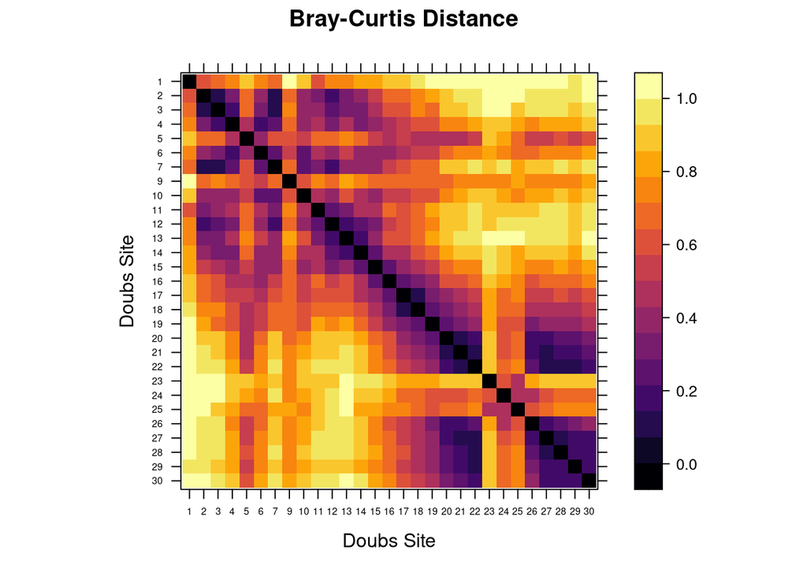

```r
#Define Order of Sites
order <- rev(attr(fish.db, "Labels"))
#Plot Heatmap
levelplot(as.matrix(fish.db)[,order], aspect = "iso", col.regions = inferno,
          xlab = "Doubs Site", ylab = "Doubs Site", scales = list(cex = 0.5),
          main = "Bray-Curtis Distance")
```

### B. Cluster Analysis

In the R code chunk below, do the following:

1. perform a cluster analysis using Ward’s Clustering, and
2. plot your cluster analysis (use either `hclust` or `heatmap.2`).

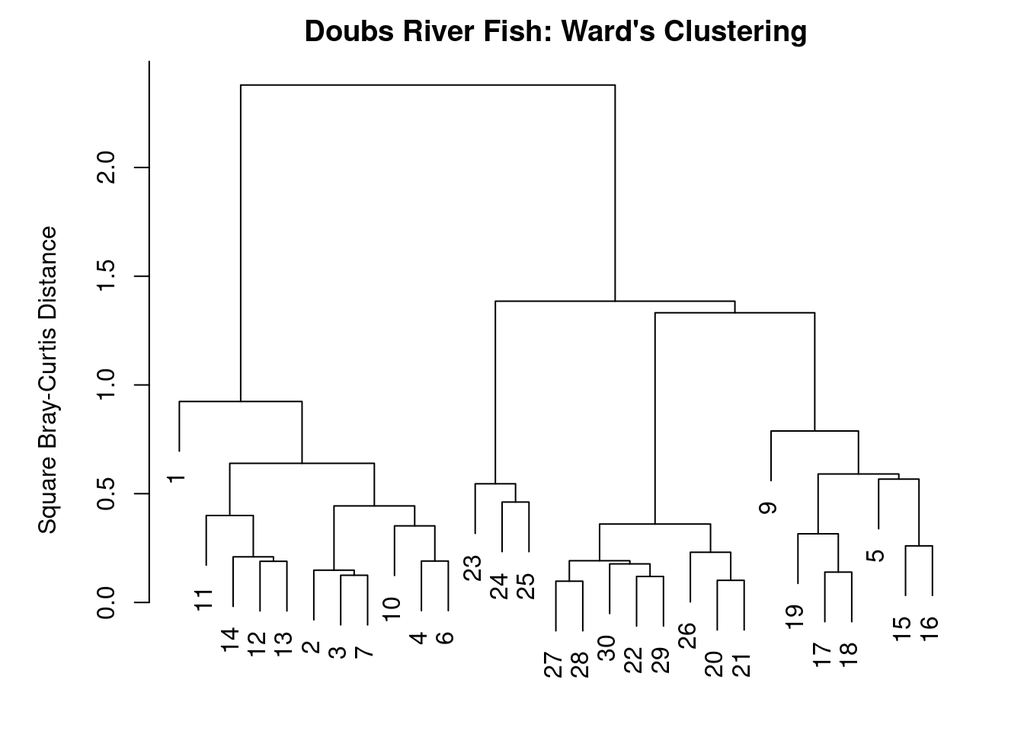

```r
#Perform Cluster Analysis
fish.ward <- hclust(fish.db, method = "ward.D2")
#Plot Cluster
par(mar = c(1,5,2,2) + 0.1)
plot(fish.ward, main = "Doubs River Fish: Ward's Clustering", ylab = "Square Bray-Curtis Distance")
```

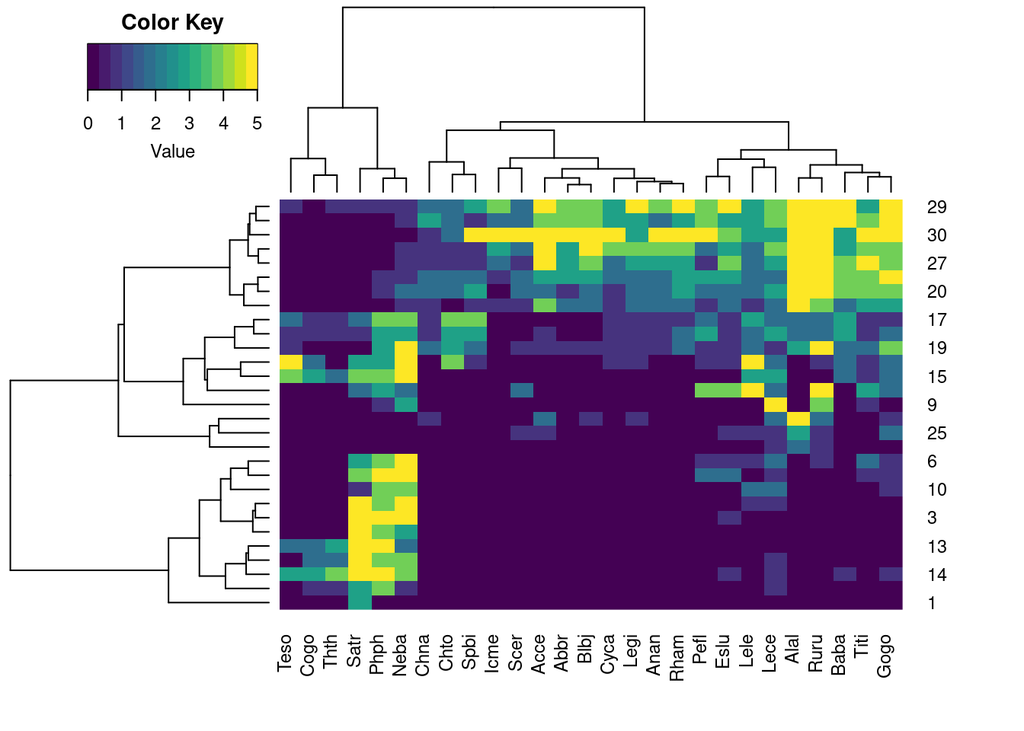

```r
gplots::heatmap.2(as.matrix(fish),
                 distfun = function(x) vegdist(x, method = "bray"),
                 hclustfun = function(x) hclust(x, method = "ward.D2"),
                 col = viridis, trace = "none", density.info = "none")
```

> *Answer 6*: Based off of what we are seeing, I am inclined to hypothesized that sites 15 - 30 are close in proximity and sites 1 - 14 are closer in proximity. This could imply that there is a downstream/upstream component in terms of how the fish are being measured where certain species of fish reside either downstream or upstream, or are capable of moving between them. For example, site 5 shows relatively similar similarity across almost all sites. I would hypothesize that sites 1-14 are either downstream/upstream and sites 15 - 30 are the opposite.

### Principal Coordinates Analysis (PCoA)

In the R code chunk below, do the following:

1. perform a Principal Coordinates Analysis to visualize beta-diversity
2. calculate the variation explained by the first three axes in your ordination
3. plot the PCoA ordination,
4. label the sites as points using the Doubs River site number, and
5. identify influential species and add species coordinates to PCoA plot.

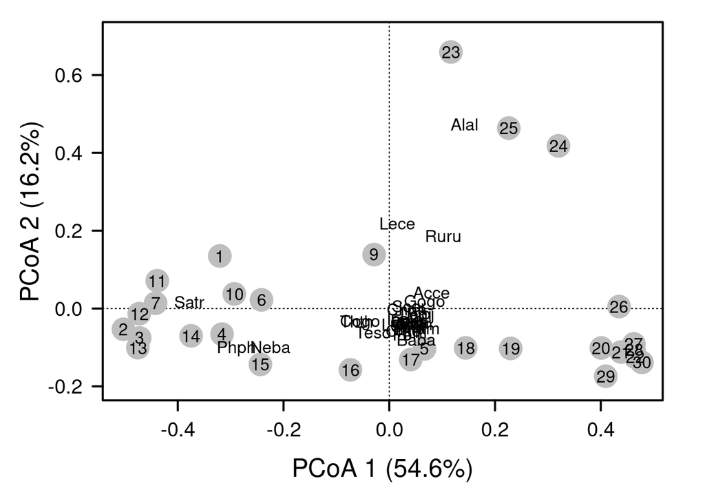

```r
fish.pcoa <- cmdscale(fish.db, eig = TRUE, k = 3)
explainvar1 <- round(fish.pcoa$eig[1]/sum(fish.pcoa$eig), 3) * 100
explainvar2 <- round(fish.pcoa$eig[2]/sum(fish.pcoa$eig), 3) * 100
explainvar3 <- round(fish.pcoa$eig[3]/sum(fish.pcoa$eig), 3) * 100
sum.eig <- sum(explainvar1, explainvar2, explainvar3)

#Define Plot Parameters
par(mar = c(5, 5, 1, 2) + 0.1)
#Initiate Plot
plot(fish.pcoa$points[,1], fish.pcoa$points[,2], ylim = c(-0.2, 0.7),
     xlab = paste("PCoA 1 (", explainvar1, "%)", sep = ""),
     ylab = paste("PCoA 2 (", explainvar2, "%)", sep = ""),
     pch = 16, cex = 2.0, type = "n", cex.lab = 1.5,
     cex.axis = 1.2, axes = FALSE)

#Add Axes
axis(side = 1, labels = T, lwd.ticks = 2, cex.axis = 1.2, las = 1)
axis(side = 2, labels = T, lwd.ticks = 2, cex.axis = 1.2, las = 1)
abline(h = 0, v = 0, lty = 3)
box(lwd = 2)

#Add Points and Labels
points(fish.pcoa$points[,1], fish.pcoa$points[,2],
       pch = 19, cex = 3, bg = "gray", col = "gray")
text(fish.pcoa$points[,1], fish.pcoa$points[,2],
     labels = row.names(fish.pcoa$points))

#First we calculate the relative abundances of each species at each site
fishREL <- fish
for(i in 1:nrow(fish)){
  fishREL[i, ] =fish[i, ] / sum(fish[i, ])
}

add.spec.scores.class <- function(ordi,comm,method="cor.scores",multi=1,Rscale=F,scaling="1") {
    ordiscores <- scores(ordi,display="sites")
    n <- ncol(comm)
    p <- ncol(ordiscores)
    specscores <- array(NA,dim=c(n,p))
    rownames(specscores) <- colnames(comm)
    colnames(specscores) <- colnames(ordiscores)
    if (method == "cor.scores") {
      for (i in 1:n) {
        for (j in 1:p) {specscores[i,j] <- cor(comm[,i],ordiscores[,j],method="pearson")}
      }
    }
    if (method == "wa.scores") {specscores <- wascores(ordiscores,comm)}
    if (method == "pcoa.scores") {
      rownames(ordiscores) <- rownames(comm)
      eigenv <- ordi$eig
      accounted <- sum(eigenv)
      tot <- 2*(accounted/ordi$GOF[2])-(accounted/ordi$GOF[1])
      eigen.var <- eigenv/(nrow(comm)-1)
      neg <- length(eigenv[eigenv<0])
      pos <- length(eigenv[eigenv>0])
      tot <- tot/(nrow(comm)-1)
      eigen.percen <- 100*eigen.var/tot
      eigen.cumpercen <- cumsum(eigen.percen)
      constant <- ((nrow(comm)-1)*tot)^0.25
      ordiscores <- ordiscores * (nrow(comm)-1)^-0.5 * tot^-0.5 * constant
      p1 <- min(p, pos)
      for (i in 1:n) {
        for (j in 1:p1) {
          specscores[i,j] <- cor(comm[,i],ordiscores[,j])*sd(comm[,i])/sd(ordiscores[,j])
          if(is.na(specscores[i,j])) {specscores[i,j]<-0}
        }
      }
      if (Rscale==T && scaling=="2") {
        percen <- eigen.var/tot
        percen <- percen^0.5
        ordiscores <- sweep(ordiscores,2,percen,"/")
        specscores <- sweep(specscores,2,percen,"*")
      }
      if (Rscale==F) {
        specscores <- specscores / constant
        ordiscores <- ordi$points
      }
      ordi$points <- ordiscores
      ordi$eig <- eigen.var
      ordi$eig.percen <- eigen.percen
      ordi$eig.cumpercen <- eigen.cumpercen
      ordi$eigen.total <- tot
      ordi$R.constant <- constant
      ordi$Rscale <- Rscale
      ordi$scaling <- scaling
    }
    specscores <- specscores * multi
    ordi$cproj <- specscores
    return(ordi)
  }


#Now we will use the relative abundances of each species at each site to calcualte and add species scores
library(vegan)
fish.pcoa <- add.spec.scores.class(fish.pcoa,fishREL, method = "pcoa.scores")
text(fish.pcoa$cproj[,1], fish.pcoa$cproj[,2],
     labels = row.names(fish.pcoa$cproj), col = "black")
```

In the R code chunk below, do the following:

1. identify influential species based on correlations along each PCoA axis (use a cutoff of 0.70), and
2. use a permutation test (999 permutations) to test the correlations of each species along each axis.

```r
spe.corr <- add.spec.scores.class(fish.pcoa, fishREL, method = "cor.scores")$cproj
corrcut <- 0.7 #user defined cutoff
imp.spp <- spe.corr[abs(spe.corr[,1]) >= corrcut | abs(spe.corr[,2]) >= corrcut, ]

#Permutation test for Spcies Abundances Acros Axes
fit <- envfit(fish.pcoa, fishREL, perm = 999)


#Create "Factors" vector
quality <- c(rep("HQ", 13), rep("MQ", 5), rep("LQ", 6), rep("MQ", 5))
#Run PERMANOVA with adonis function
adonis2(fish ~ quality, method = "bray", permutations = 999)
```

|  | Df | SumOfSqs | R2 | F | Pr(>F) |
| --- | --- | --- | --- | --- | --- |
| Model | 2 | 3.094669 | 0.4576506 | 10.96979 | 0.001 |
| Residual | 26 | 3.667409 | 0.5423494 | NA | NA |
| Total | 28 | 6.762078 | 1.0000000 | NA | NA |

*Question 7*: Address the following questions about the ordination results of the `doubs` data set:

1. Describe the grouping of sites in the Doubs River based on fish community composition.
2. Generate a hypothesis about which fish species are potential indicators of river quality.

## SYNTHESIS

Load the dataset from that you and your partner are using for the team project. Use one of the tools introduced in the beta diversity module to visualize your data. Describe any interesting patterns and identify a hypothesis is relevant to the principles of biodiversity.

```r
Projdata <- read.csv("/cloud/project/QB2025_Guevara/Week2-Alpha/MAT_fungal_abundances.csv")
str(Projdata)
```

```
## 'data.frame':    704 obs. of  12 variables:
##  $ Plot              : chr  "MAT.B1.C" "MAT.B1.C" "MAT.B1.C" "MAT.B1.C" ...
##  $ Block             : chr  "B1" "B1" "B1" "B1" ...
##  $ Treatment         : chr  "Control" "Control" "Control" "Control" ...
##  $ OTU               : chr  "X1" "X2" "X3" "X4" ...
##  $ Species           : chr  "Alternaria_alternata" "Articulospora_tetracladia" "Cadophora_finlandica" "Cenococcum_geophilum" ...
##  $ Genus             : chr  "Alternaria" "Articulospora" "Cadophora" "Cenococcum" ...
##  $ Family            : chr  "Pleosporaceae" "Helotiaceae" "Helotiaceae" "Gloniaceae" ...
##  $ Order             : chr  "Pleosporales" "Helotiales" "Helotiales" "Mytilinidiales" ...
##  $ Phylum            : chr  "Ascomycota" "Ascomycota" "Ascomycota" "Ascomycota" ...
##  $ Relative.Abundance: num  0.0345 0 0 0.0345 0 ...
##  $ EcM.density       : num  0.679 0.679 0.679 0.679 0.679 ...
##  $ Absolute.Abundance: num  0.0234 0 0 0.0234 0 ...
```

```r
#To slim down the data to only columns I will need
library(dplyr)
```

```r
slim <- Projdata %>%
  select(Plot, Treatment, Species, Relative.Abundance)
slim
```

| Plot | Treatment | Species | Relative.Abundance |
| --- | --- | --- | --- |
| MAT.B1.C | Control | Alternaria_alternata | 0.03448276 |
| MAT.B1.C | Control | Articulospora_tetracladia | 0.00000000 |
| MAT.B1.C | Control | Cadophora_finlandica | 0.00000000 |
| MAT.B1.C | Control | Cenococcum_geophilum | 0.03448276 |
| MAT.B1.C | Control | Chalara_sp._1 | 0.00000000 |
| MAT.B1.C | Control | Cortinarius_sp._1 | 0.37931034 |
| MAT.B1.C | Control | Cortinarius_croceus_1 | 0.03448276 |
| MAT.B1.C | Control | Cortinarius_glandicolor | 0.03448276 |
| MAT.B1.C | Control | Cortinarius_casimiri | 0.00000000 |
| MAT.B1.C | Control | Cortinarius_croceus_2 | 0.00000000 |

[output cut: 694 more lines]

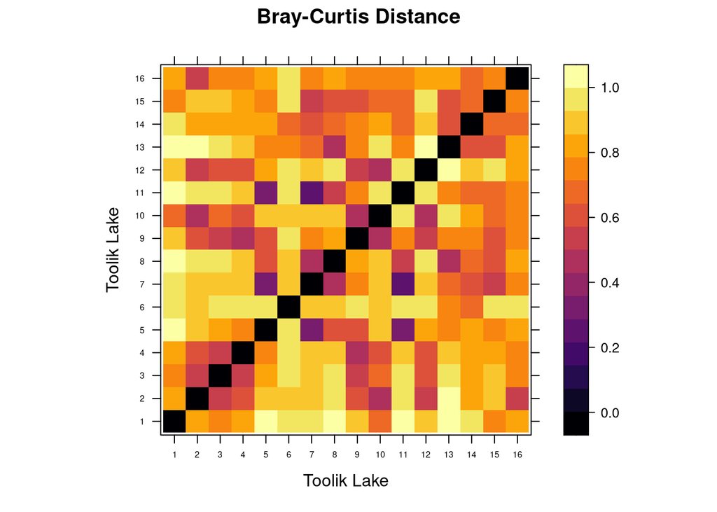

```r
##
#Changing data so that each species is a column, values are the relative.abundance, and rows are each plot/site
library(tidyr)
ExpandProjdata <- slim %>%
  pivot_wider(names_from = Species, values_from = Relative.Abundance, values_fill = 0)
Sorted_ExpandProjdata <- ExpandProjdata %>%
  arrange(Treatment)
ExpandProjdata.db <- vegdist(Sorted_ExpandProjdata[, -c(1,2)], method = "bray", upper = TRUE, diag = TRUE)

#Define Order of Sites
order.projdata <- rev(attr(ExpandProjdata.db, "Labels"))


heatmap_matrix <- as.matrix(ExpandProjdata.db)

# Ensure rows and columns match the order
if (!is.null(order.projdata)) {
  heatmap_matrix <- heatmap_matrix[order.projdata, order.projdata]
}

# Now plot
levelplot(heatmap_matrix, aspect = "iso", col.regions = inferno,
          xlab = "Toolik Lake", ylab = "Toolik Lake", scales = list(cex = 0.5),
          main = "Bray-Curtis Distance")
```

```r
#After having reorganized my data so that sites are sorted by treatment group, it is difficult to detect but it appears there may be a slight pattern where different locations that are undergo the same treatment (either cntrl, fertilized, warmed, or warmed & fertilized) exhibit greater similarities in beta diversity than when compared to the same sight but of another treatment group.
```